# Risk Factor Analysis

## Outcome Variable

**Outcome Variable:** co_occurence

## Predictor Variables

**Intervention Variable:** ever_stunted06

**Adjustment Set:**

- sex
- arm
- enstunt
- month
- brthmon
- hhwealth_quart
- W_birthwt
- W_birthlen
- W_mage
- W_mhtcm
- W_meducyrs
- W_feducyrs
- delta_month
- delta_brthmon
- delta_hhwealth_quart
- delta_W_birthwt
- delta_W_birthlen
- delta_W_mage
- delta_W_mhtcm
- delta_W_meducyrs
- delta_W_feducyrs

## Stratifying Variables

The analysis was stratified on these variable(s):

- studyid
- country

## Data Summary

| studyid | country | ever_stunted06 | co_occurence | n_cell | n |
| --- | --- | --- | --- | --- | --- |
| ki0047075b-MAL-ED | BANGLADESH | 0 | 0 | 144 | 221 |
| ki0047075b-MAL-ED | BANGLADESH | 0 | 1 | 5 | 221 |
| ki0047075b-MAL-ED | BANGLADESH | 1 | 0 | 63 | 221 |
| ki0047075b-MAL-ED | BANGLADESH | 1 | 1 | 9 | 221 |
| ki0047075b-MAL-ED | BRAZIL | 0 | 0 | 147 | 180 |
| ki0047075b-MAL-ED | BRAZIL | 0 | 1 | 0 | 180 |
| ki0047075b-MAL-ED | BRAZIL | 1 | 0 | 32 | 180 |
| ki0047075b-MAL-ED | BRAZIL | 1 | 1 | 1 | 180 |
| ki0047075b-MAL-ED | INDIA | 0 | 0 | 143 | 228 |
| ki0047075b-MAL-ED | INDIA | 0 | 1 | 7 | 228 |
| ki0047075b-MAL-ED | INDIA | 1 | 0 | 68 | 228 |
| ki0047075b-MAL-ED | INDIA | 1 | 1 | 10 | 228 |
| ki0047075b-MAL-ED | NEPAL | 0 | 0 | 189 | 229 |
| ki0047075b-MAL-ED | NEPAL | 0 | 1 | 1 | 229 |
| ki0047075b-MAL-ED | NEPAL | 1 | 0 | 36 | 229 |
| ki0047075b-MAL-ED | NEPAL | 1 | 1 | 3 | 229 |
| ki0047075b-MAL-ED | PERU | 0 | 0 | 118 | 222 |
| ki0047075b-MAL-ED | PERU | 0 | 1 | 0 | 222 |
| ki0047075b-MAL-ED | PERU | 1 | 0 | 98 | 222 |
| ki0047075b-MAL-ED | PERU | 1 | 1 | 6 | 222 |
| ki0047075b-MAL-ED | SOUTH AFRICA | 0 | 0 | 145 | 241 |
| ki0047075b-MAL-ED | SOUTH AFRICA | 0 | 1 | 2 | 241 |
| ki0047075b-MAL-ED | SOUTH AFRICA | 1 | 0 | 92 | 241 |
| ki0047075b-MAL-ED | SOUTH AFRICA | 1 | 1 | 2 | 241 |
| ki0047075b-MAL-ED | TANZANIA, UNITED REPUBLIC OF | 0 | 0 | 135 | 225 |
| ki0047075b-MAL-ED | TANZANIA, UNITED REPUBLIC OF | 0 | 1 | 0 | 225 |
| ki0047075b-MAL-ED | TANZANIA, UNITED REPUBLIC OF | 1 | 0 | 89 | 225 |
| ki0047075b-MAL-ED | TANZANIA, UNITED REPUBLIC OF | 1 | 1 | 1 | 225 |
| ki1000108-CMC-V-BCS-2002 | INDIA | 0 | 0 | 172 | 364 |
| ki1000108-CMC-V-BCS-2002 | INDIA | 0 | 1 | 8 | 364 |

[output cut: 102 more lines]

The following strata were considered:

- studyid: ki0047075b-MAL-ED, country: BANGLADESH
- studyid: ki0047075b-MAL-ED, country: BRAZIL
- studyid: ki0047075b-MAL-ED, country: INDIA
- studyid: ki0047075b-MAL-ED, country: NEPAL
- studyid: ki0047075b-MAL-ED, country: PERU
- studyid: ki0047075b-MAL-ED, country: SOUTH AFRICA
- studyid: ki0047075b-MAL-ED, country: TANZANIA, UNITED REPUBLIC OF
- studyid: ki1000108-CMC-V-BCS-2002, country: INDIA
- studyid: ki1000108-IRC, country: INDIA
- studyid: ki1000109-EE, country: PAKISTAN
- studyid: ki1000109-ResPak, country: PAKISTAN
- studyid: ki1000304b-SAS-CompFeed, country: INDIA
- studyid: ki1000304b-SAS-FoodSuppl, country: INDIA
- studyid: ki1017093-NIH-Birth, country: BANGLADESH
- studyid: ki1017093b-PROVIDE, country: BANGLADESH
- studyid: ki1017093c-NIH-Crypto, country: BANGLADESH
- studyid: ki1066203-TanzaniaChild2, country: TANZANIA, UNITED REPUBLIC OF
- studyid: ki1101329-Keneba, country: GAMBIA
- studyid: ki1112895-Burkina Faso Zn, country: BURKINA FASO
- studyid: ki1113344-GMS-Nepal, country: NEPAL
- studyid: ki1114097-CMIN, country: BANGLADESH
- studyid: ki1114097-CMIN, country: BRAZIL
- studyid: ki1114097-CMIN, country: GUINEA-BISSAU
- studyid: ki1114097-CMIN, country: PERU
- studyid: ki1114097-CONTENT, country: PERU
- studyid: ki1119695-PROBIT, country: BELARUS
- studyid: ki1126311-ZVITAMBO, country: ZIMBABWE
- studyid: ki1135781-COHORTS, country: GUATEMALA
- studyid: ki1135781-COHORTS, country: PHILIPPINES
- studyid: ki1148112-iLiNS-DOSE, country: MALAWI
- studyid: ki1148112-iLiNS-DYAD-M, country: MALAWI
- studyid: ki1148112-LCNI-5, country: MALAWI
- studyid: kiGH5241-JiVitA-4, country: BANGLADESH

### Dropped Strata

Some strata were dropped due to rare outcomes:

- studyid: ki0047075b-MAL-ED, country: BRAZIL
- studyid: ki0047075b-MAL-ED, country: NEPAL
- studyid: ki0047075b-MAL-ED, country: PERU
- studyid: ki0047075b-MAL-ED, country: SOUTH AFRICA
- studyid: ki0047075b-MAL-ED, country: TANZANIA, UNITED REPUBLIC OF
- studyid: ki1000108-IRC, country: INDIA
- studyid: ki1000109-ResPak, country: PAKISTAN
- studyid: ki1112895-Burkina Faso Zn, country: BURKINA FASO
- studyid: ki1114097-CMIN, country: BRAZIL
- studyid: ki1114097-CMIN, country: PERU
- studyid: ki1114097-CONTENT, country: PERU
- studyid: ki1119695-PROBIT, country: BELARUS
- studyid: ki1148112-LCNI-5, country: MALAWI

## Methods Detail

We’re interested in the causal parameters $E[Y_a]$ for all values of $a \in \mathcal{A}$. These parameters represent the mean outcome if, possibly contrary to fact, we intervened to set all units to have $A=a$. Under the randomization and positivity assumptions, these are identified by the statistical parameters $\psi_a=E_W[E_{Y|A,W}(Y|A=a,W)]$. In addition, we’re interested in the mean of $Y$, $E[Y]$ under no intervention (the observed mean). We will estimate these parameters by using SuperLearner to fit the relevant likelihood factors – $E_{Y|A,W}(Y|A=a,W)$ and $p(A=a|W)$, and then updating our likelihood fit using a joint TMLE.

For unadjusted analyses ($W=\{\}$), initial likelihoods were estimated using Lrnr_glm to estimate the simple $E(Y|A)$ and Lrnr_mean to estimate $p(A)$. For adjusted analyses, a small library containing Lrnr_glmnet, Lrnr_xgboost, and Lrnr_mean was used.

Having estimated these parameters, we will then use the delta method to estimate relative risks and attributable risks relative to a prespecified baseline level of $A$.

# Results Detail

## Results Plots

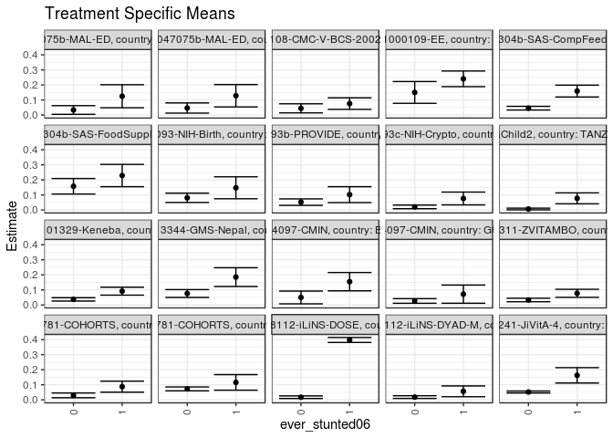

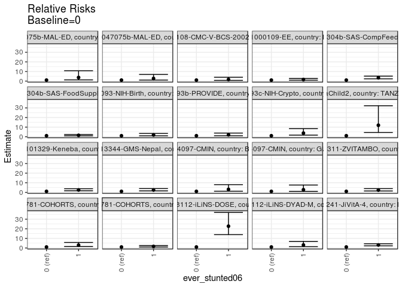

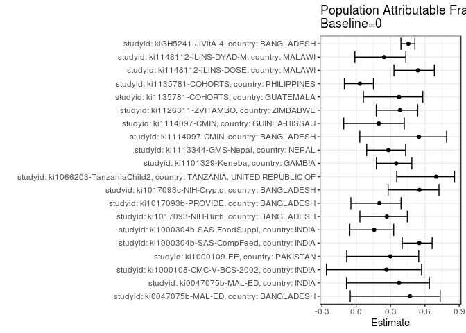

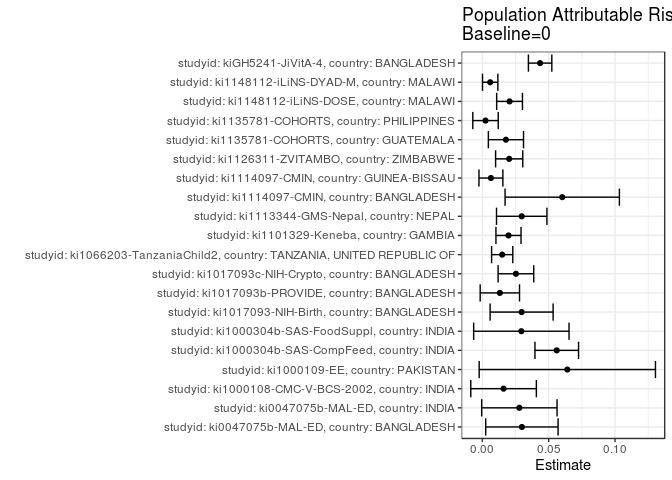

## Results Table

### Parameter: TSM

| studyid | country | intervention_level | baseline_level | estimate | ci_lower | ci_upper |
| --- | --- | --- | --- | --- | --- | --- |
| ki0047075b-MAL-ED | BANGLADESH | 0 | NA | 0.0335570 | 0.0045756 | 0.0625385 |
| ki0047075b-MAL-ED | BANGLADESH | 1 | NA | 0.1250000 | 0.0484358 | 0.2015642 |
| ki0047075b-MAL-ED | INDIA | 0 | NA | 0.0466667 | 0.0128382 | 0.0804952 |
| ki0047075b-MAL-ED | INDIA | 1 | NA | 0.1282051 | 0.0538493 | 0.2025610 |
| ki1000108-CMC-V-BCS-2002 | INDIA | 0 | NA | 0.0444444 | 0.0142973 | 0.0745916 |
| ki1000108-CMC-V-BCS-2002 | INDIA | 1 | NA | 0.0760870 | 0.0377244 | 0.1144495 |
| ki1000109-EE | PAKISTAN | 0 | NA | 0.1502566 | 0.0779046 | 0.2226085 |
| ki1000109-EE | PAKISTAN | 1 | NA | 0.2405498 | 0.1884703 | 0.2926293 |
| ki1000304b-SAS-CompFeed | INDIA | 0 | NA | 0.0456835 | 0.0334175 | 0.0579494 |
| ki1000304b-SAS-CompFeed | INDIA | 1 | NA | 0.1591921 | 0.1197092 | 0.1986750 |
| ki1000304b-SAS-FoodSuppl | INDIA | 0 | NA | 0.1575268 | 0.1059386 | 0.2091150 |
| ki1000304b-SAS-FoodSuppl | INDIA | 1 | NA | 0.2287983 | 0.1547594 | 0.3028373 |
| ki1017093-NIH-Birth | BANGLADESH | 0 | NA | 0.0807913 | 0.0497133 | 0.1118694 |
| ki1017093-NIH-Birth | BANGLADESH | 1 | NA | 0.1474228 | 0.0743876 | 0.2204581 |
| ki1017093b-PROVIDE | BANGLADESH | 0 | NA | 0.0521426 | 0.0306335 | 0.0736516 |
| ki1017093b-PROVIDE | BANGLADESH | 1 | NA | 0.1019100 | 0.0491099 | 0.1547101 |
| ki1017093c-NIH-Crypto | BANGLADESH | 0 | NA | 0.0204488 | 0.0083564 | 0.0325412 |
| ki1017093c-NIH-Crypto | BANGLADESH | 1 | NA | 0.0763962 | 0.0338248 | 0.1189675 |
| ki1066203-TanzaniaChild2 | TANZANIA, UNITED REPUBLIC OF | 0 | NA | 0.0064683 | 0.0008142 | 0.0121224 |
| ki1066203-TanzaniaChild2 | TANZANIA, UNITED REPUBLIC OF | 1 | NA | 0.0772947 | 0.0408956 | 0.1136938 |
| ki1101329-Keneba | GAMBIA | 0 | NA | 0.0366735 | 0.0255986 | 0.0477484 |
| ki1101329-Keneba | GAMBIA | 1 | NA | 0.0913442 | 0.0650062 | 0.1176823 |
| ki1113344-GMS-Nepal | NEPAL | 0 | NA | 0.0757885 | 0.0497985 | 0.1017785 |
| ki1113344-GMS-Nepal | NEPAL | 1 | NA | 0.1848264 | 0.1225799 | 0.2470728 |
| ki1114097-CMIN | BANGLADESH | 0 | NA | 0.0495050 | 0.0071109 | 0.0918990 |
| ki1114097-CMIN | BANGLADESH | 1 | NA | 0.1544118 | 0.0935539 | 0.2152696 |
| ki1114097-CMIN | GUINEA-BISSAU | 0 | NA | 0.0261905 | 0.0109016 | 0.0414794 |
| ki1114097-CMIN | GUINEA-BISSAU | 1 | NA | 0.0714286 | 0.0110356 | 0.1318215 |
| ki1126311-ZVITAMBO | ZIMBABWE | 0 | NA | 0.0326596 | 0.0209883 | 0.0443308 |
| ki1126311-ZVITAMBO | ZIMBABWE | 1 | NA | 0.0772116 | 0.0505292 | 0.1038941 |
| ki1135781-COHORTS | GUATEMALA | 0 | NA | 0.0297671 | 0.0141352 | 0.0453991 |
| ki1135781-COHORTS | GUATEMALA | 1 | NA | 0.0875673 | 0.0509472 | 0.1241873 |
| ki1135781-COHORTS | PHILIPPINES | 0 | NA | 0.0728013 | 0.0598434 | 0.0857592 |
| ki1135781-COHORTS | PHILIPPINES | 1 | NA | 0.1160095 | 0.0642659 | 0.1677530 |
| ki1148112-iLiNS-DOSE | MALAWI | 0 | NA | 0.0175548 | 0.0089563 | 0.0261533 |
| ki1148112-iLiNS-DOSE | MALAWI | 1 | NA | 0.3979781 | 0.3814411 | 0.4145151 |
| ki1148112-iLiNS-DYAD-M | MALAWI | 0 | NA | 0.0183908 | 0.0094584 | 0.0273232 |
| ki1148112-iLiNS-DYAD-M | MALAWI | 1 | NA | 0.0566038 | 0.0206677 | 0.0925398 |
| kiGH5241-JiVitA-4 | BANGLADESH | 0 | NA | 0.0521068 | 0.0456228 | 0.0585908 |
| kiGH5241-JiVitA-4 | BANGLADESH | 1 | NA | 0.1629792 | 0.1119505 | 0.2140078 |

### Parameter: E(Y)

| studyid | country | intervention_level | baseline_level | estimate | ci_lower | ci_upper |
| --- | --- | --- | --- | --- | --- | --- |
| ki0047075b-MAL-ED | BANGLADESH | NA | NA | 0.0633484 | 0.0311604 | 0.0955364 |
| ki0047075b-MAL-ED | INDIA | NA | NA | 0.0745614 | 0.0403897 | 0.1087331 |
| ki1000108-CMC-V-BCS-2002 | INDIA | NA | NA | 0.0604396 | 0.0359254 | 0.0849538 |
| ki1000109-EE | PAKISTAN | NA | NA | 0.2142857 | 0.1712366 | 0.2573348 |
| ki1000304b-SAS-CompFeed | INDIA | NA | NA | 0.1017488 | 0.0903508 | 0.1131468 |
| ki1000304b-SAS-FoodSuppl | INDIA | NA | NA | 0.1869159 | 0.1442025 | 0.2296293 |
| ki1017093-NIH-Birth | BANGLADESH | NA | NA | 0.1103896 | 0.0817833 | 0.1389959 |
| ki1017093b-PROVIDE | BANGLADESH | NA | NA | 0.0653358 | 0.0446834 | 0.0859881 |
| ki1017093c-NIH-Crypto | BANGLADESH | NA | NA | 0.0457413 | 0.0294659 | 0.0620168 |
| ki1066203-TanzaniaChild2 | TANZANIA, UNITED REPUBLIC OF | NA | NA | 0.0214286 | 0.0123577 | 0.0304995 |
| ki1101329-Keneba | GAMBIA | NA | NA | 0.0563698 | 0.0456344 | 0.0671052 |
| ki1113344-GMS-Nepal | NEPAL | NA | NA | 0.1054545 | 0.0797627 | 0.1311464 |
| ki1114097-CMIN | BANGLADESH | NA | NA | 0.1097046 | 0.0698323 | 0.1495770 |
| ki1114097-CMIN | GUINEA-BISSAU | NA | NA | 0.0326531 | 0.0169007 | 0.0484055 |
| ki1126311-ZVITAMBO | ZIMBABWE | NA | NA | 0.0528846 | 0.0421282 | 0.0636410 |
| ki1135781-COHORTS | GUATEMALA | NA | NA | 0.0475524 | 0.0319423 | 0.0631626 |
| ki1135781-COHORTS | PHILIPPINES | NA | NA | 0.0751910 | 0.0648251 | 0.0855569 |
| ki1148112-iLiNS-DOSE | MALAWI | NA | NA | 0.0380623 | 0.0253182 | 0.0508064 |
| ki1148112-iLiNS-DYAD-M | MALAWI | NA | NA | 0.0242954 | 0.0148836 | 0.0337072 |
| kiGH5241-JiVitA-4 | BANGLADESH | NA | NA | 0.0956346 | 0.0850945 | 0.1061746 |

### Parameter: RR

| studyid | country | intervention_level | baseline_level | estimate | ci_lower | ci_upper |
| --- | --- | --- | --- | --- | --- | --- |
| ki0047075b-MAL-ED | BANGLADESH | 0 | 0 | 1.000000 | 1.0000000 | 1.000000 |
| ki0047075b-MAL-ED | BANGLADESH | 1 | 0 | 3.725000 | 1.2920971 | 10.738840 |
| ki0047075b-MAL-ED | INDIA | 0 | 0 | 1.000000 | 1.0000000 | 1.000000 |
| ki0047075b-MAL-ED | INDIA | 1 | 0 | 2.747253 | 1.0857212 | 6.951506 |
| ki1000108-CMC-V-BCS-2002 | INDIA | 0 | 0 | 1.000000 | 1.0000000 | 1.000000 |
| ki1000108-CMC-V-BCS-2002 | INDIA | 1 | 0 | 1.711957 | 0.7352570 | 3.986082 |
| ki1000109-EE | PAKISTAN | 0 | 0 | 1.000000 | 1.0000000 | 1.000000 |
| ki1000109-EE | PAKISTAN | 1 | 0 | 1.600927 | 0.9431859 | 2.717350 |
| ki1000304b-SAS-CompFeed | INDIA | 0 | 0 | 1.000000 | 1.0000000 | 1.000000 |
| ki1000304b-SAS-CompFeed | INDIA | 1 | 0 | 3.484677 | 2.3509607 | 5.165111 |
| ki1000304b-SAS-FoodSuppl | INDIA | 0 | 0 | 1.000000 | 1.0000000 | 1.000000 |
| ki1000304b-SAS-FoodSuppl | INDIA | 1 | 0 | 1.452441 | 0.9162389 | 2.302439 |
| ki1017093-NIH-Birth | BANGLADESH | 0 | 0 | 1.000000 | 1.0000000 | 1.000000 |
| ki1017093-NIH-Birth | BANGLADESH | 1 | 0 | 1.824736 | 0.9740753 | 3.418280 |
| ki1017093b-PROVIDE | BANGLADESH | 0 | 0 | 1.000000 | 1.0000000 | 1.000000 |
| ki1017093b-PROVIDE | BANGLADESH | 1 | 0 | 1.954448 | 1.0086881 | 3.786967 |
| ki1017093c-NIH-Crypto | BANGLADESH | 0 | 0 | 1.000000 | 1.0000000 | 1.000000 |
| ki1017093c-NIH-Crypto | BANGLADESH | 1 | 0 | 3.735974 | 1.6573754 | 8.421448 |
| ki1066203-TanzaniaChild2 | TANZANIA, UNITED REPUBLIC OF | 0 | 0 | 1.000000 | 1.0000000 | 1.000000 |
| ki1066203-TanzaniaChild2 | TANZANIA, UNITED REPUBLIC OF | 1 | 0 | 11.949758 | 4.4273686 | 32.253178 |
| ki1101329-Keneba | GAMBIA | 0 | 0 | 1.000000 | 1.0000000 | 1.000000 |
| ki1101329-Keneba | GAMBIA | 1 | 0 | 2.490743 | 1.6427006 | 3.776587 |
| ki1113344-GMS-Nepal | NEPAL | 0 | 0 | 1.000000 | 1.0000000 | 1.000000 |
| ki1113344-GMS-Nepal | NEPAL | 1 | 0 | 2.438712 | 1.5063668 | 3.948120 |
| ki1114097-CMIN | BANGLADESH | 0 | 0 | 1.000000 | 1.0000000 | 1.000000 |
| ki1114097-CMIN | BANGLADESH | 1 | 0 | 3.119118 | 1.2151260 | 8.006491 |
| ki1114097-CMIN | GUINEA-BISSAU | 0 | 0 | 1.000000 | 1.0000000 | 1.000000 |
| ki1114097-CMIN | GUINEA-BISSAU | 1 | 0 | 2.727273 | 0.9761452 | 7.619785 |
| ki1126311-ZVITAMBO | ZIMBABWE | 0 | 0 | 1.000000 | 1.0000000 | 1.000000 |
| ki1126311-ZVITAMBO | ZIMBABWE | 1 | 0 | 2.364135 | 1.4374124 | 3.888330 |
| ki1135781-COHORTS | GUATEMALA | 0 | 0 | 1.000000 | 1.0000000 | 1.000000 |
| ki1135781-COHORTS | GUATEMALA | 1 | 0 | 2.941745 | 1.5025498 | 5.759453 |
| ki1135781-COHORTS | PHILIPPINES | 0 | 0 | 1.000000 | 1.0000000 | 1.000000 |
| ki1135781-COHORTS | PHILIPPINES | 1 | 0 | 1.593508 | 0.9863804 | 2.574331 |
| ki1148112-iLiNS-DOSE | MALAWI | 0 | 0 | 1.000000 | 1.0000000 | 1.000000 |
| ki1148112-iLiNS-DOSE | MALAWI | 1 | 0 | 22.670631 | 13.8964682 | 36.984758 |
| ki1148112-iLiNS-DYAD-M | MALAWI | 0 | 0 | 1.000000 | 1.0000000 | 1.000000 |
| ki1148112-iLiNS-DYAD-M | MALAWI | 1 | 0 | 3.077830 | 1.3838532 | 6.845407 |
| kiGH5241-JiVitA-4 | BANGLADESH | 0 | 0 | 1.000000 | 1.0000000 | 1.000000 |
| kiGH5241-JiVitA-4 | BANGLADESH | 1 | 0 | 3.127792 | 2.2355352 | 4.376171 |

### Parameter: PAR

| studyid | country | intervention_level | baseline_level | estimate | ci_lower | ci_upper |
| --- | --- | --- | --- | --- | --- | --- |
| ki0047075b-MAL-ED | BANGLADESH | 0 | NA | 0.0297914 | 0.0025256 | 0.0570572 |
| ki0047075b-MAL-ED | INDIA | 0 | NA | 0.0278947 | -0.0005011 | 0.0562906 |
| ki1000108-CMC-V-BCS-2002 | INDIA | 0 | NA | 0.0159951 | -0.0087220 | 0.0407122 |
| ki1000109-EE | PAKISTAN | 0 | NA | 0.0640291 | -0.0023886 | 0.1304469 |
| ki1000304b-SAS-CompFeed | INDIA | 0 | NA | 0.0560653 | 0.0396379 | 0.0724927 |
| ki1000304b-SAS-FoodSuppl | INDIA | 0 | NA | 0.0293891 | -0.0065445 | 0.0653227 |
| ki1017093-NIH-Birth | BANGLADESH | 0 | NA | 0.0295983 | 0.0058669 | 0.0533297 |
| ki1017093b-PROVIDE | BANGLADESH | 0 | NA | 0.0131932 | -0.0016273 | 0.0280136 |
| ki1017093c-NIH-Crypto | BANGLADESH | 0 | NA | 0.0252925 | 0.0118760 | 0.0387091 |
| ki1066203-TanzaniaChild2 | TANZANIA, UNITED REPUBLIC OF | 0 | NA | 0.0149603 | 0.0069717 | 0.0229488 |
| ki1101329-Keneba | GAMBIA | 0 | NA | 0.0196963 | 0.0102400 | 0.0291526 |
| ki1113344-GMS-Nepal | NEPAL | 0 | NA | 0.0296660 | 0.0106768 | 0.0486553 |
| ki1114097-CMIN | BANGLADESH | 0 | NA | 0.0601997 | 0.0171274 | 0.1032720 |
| ki1114097-CMIN | GUINEA-BISSAU | 0 | NA | 0.0064626 | -0.0025471 | 0.0154722 |
| ki1126311-ZVITAMBO | ZIMBABWE | 0 | NA | 0.0202251 | 0.0099935 | 0.0304566 |
| ki1135781-COHORTS | GUATEMALA | 0 | NA | 0.0177853 | 0.0045355 | 0.0310352 |
| ki1135781-COHORTS | PHILIPPINES | 0 | NA | 0.0023897 | -0.0071887 | 0.0119681 |
| ki1148112-iLiNS-DOSE | MALAWI | 0 | NA | 0.0205075 | 0.0107890 | 0.0302260 |
| ki1148112-iLiNS-DYAD-M | MALAWI | 0 | NA | 0.0059046 | 0.0001209 | 0.0116884 |
| kiGH5241-JiVitA-4 | BANGLADESH | 0 | NA | 0.0435278 | 0.0347040 | 0.0523516 |

### Parameter: PAF

| studyid | country | intervention_level | baseline_level | estimate | ci_lower | ci_upper |
| --- | --- | --- | --- | --- | --- | --- |
| ki0047075b-MAL-ED | BANGLADESH | 0 | NA | 0.4702780 | -0.0524278 | 0.7333733 |
| ki0047075b-MAL-ED | INDIA | 0 | NA | 0.3741176 | -0.0850804 | 0.6389865 |
| ki1000108-CMC-V-BCS-2002 | INDIA | 0 | NA | 0.2646464 | -0.2599934 | 0.5708352 |
| ki1000109-EE | PAKISTAN | 0 | NA | 0.2988027 | -0.0831558 | 0.5460692 |
| ki1000304b-SAS-CompFeed | INDIA | 0 | NA | 0.5510172 | 0.4017536 | 0.6630392 |
| ki1000304b-SAS-FoodSuppl | INDIA | 0 | NA | 0.1572316 | -0.0562343 | 0.3275558 |
| ki1017093-NIH-Birth | BANGLADESH | 0 | NA | 0.2681258 | 0.0319463 | 0.4466837 |
| ki1017093b-PROVIDE | BANGLADESH | 0 | NA | 0.2019287 | -0.0467062 | 0.3915029 |
| ki1017093c-NIH-Crypto | BANGLADESH | 0 | NA | 0.5529470 | 0.2784224 | 0.7230286 |
| ki1066203-TanzaniaChild2 | TANZANIA, UNITED REPUBLIC OF | 0 | NA | 0.6981457 | 0.3537738 | 0.8590029 |
| ki1101329-Keneba | GAMBIA | 0 | NA | 0.3494122 | 0.1763381 | 0.4861187 |
| ki1113344-GMS-Nepal | NEPAL | 0 | NA | 0.2813158 | 0.0914300 | 0.4315166 |
| ki1114097-CMIN | BANGLADESH | 0 | NA | 0.5487433 | 0.0314149 | 0.7897628 |
| ki1114097-CMIN | GUINEA-BISSAU | 0 | NA | 0.1979167 | -0.1089310 | 0.4198578 |
| ki1126311-ZVITAMBO | ZIMBABWE | 0 | NA | 0.3824374 | 0.1750562 | 0.5376853 |
| ki1135781-COHORTS | GUATEMALA | 0 | NA | 0.3740152 | 0.0629004 | 0.5818407 |
| ki1135781-COHORTS | PHILIPPINES | 0 | NA | 0.0317819 | -0.1036624 | 0.1506041 |
| ki1148112-iLiNS-DOSE | MALAWI | 0 | NA | 0.5387879 | 0.3298093 | 0.6826029 |
| ki1148112-iLiNS-DYAD-M | MALAWI | 0 | NA | 0.2430345 | -0.0114858 | 0.4335098 |
| kiGH5241-JiVitA-4 | BANGLADESH | 0 | NA | 0.4551470 | 0.3906257 | 0.5128366 |